# HW 6 - Avian Pox

Keanu Rochette

2025-02-25

## Load libraries

```r
# Data manipulation and visualization
library(tidyverse)
library(here)
library(janitor)
library(gt)
library(gtExtras)

# Data analysis/statistics
library(car) #ANOVA
library(ggeffects)
library(effects) #dependency for ggeffects
```

## Load the functions

```r
dispersion <- function (model){
  sum(residuals(model, type = "pearson")^2)/(length(model$y)-length(model$coefficients))
}
```

## Load data

```r
avian <- read_csv(here("HW6","data","avian_pox.csv"))
```

## Data Clean-Up

```r
avian<- avian %>% clean_names() %>%
  mutate(elev = factor(elev, levels = c("low", "mid", "high")))
avian
```

```
## # A tibble: 11,743 × 11
##       x1 site  species bandno   date  sex   age   oldpox activepox malaria elev
##    <dbl> <chr> <chr>   <chr>    <chr> <chr> <chr>  <dbl>     <dbl>   <dbl> <fct>
##  1     1 AIN   APAP    1591747… 7/22… U     H          0         0       2 mid
##  2     2 AIN   APAP    1591749… 7/6/… M     H          0         1       2 mid
##  3     3 AIN   APAP    1591749… 7/7/… F     H          0         0       2 mid
##  4     4 AIN   APAP    1591749… 7/7/… F     H          0         0       2 mid
##  5     5 AIN   APAP    1591749… 7/9/… F     H          0         0       2 mid
##  6     6 AIN   APAP    1591749… 7/19… F     H          0         0       2 mid
##  7     7 AIN   APAP    1591749… 7/19… M     H          0         0       2 mid
##  8     8 AIN   APAP    1591749… 7/19… M     H          0         0       2 mid
##  9     9 AIN   APAP    1591749… 7/19… F     H          0         0       2 mid
## 10    10 AIN   APAP    1591749… 7/21… F     H          0         1       2 mid
## # ℹ 11,733 more rows
```

## Question 1

*The twelve sites have been coded as low/medium/high elevation.*  
*First, summarize the number of observations of each bird species at each elevation. This will be important context for what we can and cannot ask about avian pox patterns.*  
*Also, what is the prevalence of chronic malaria in the bird species at the difference elevations? Note that some birds do not have a known malaria status (code = 2). Only use birds with code = 0 or 1 to quantify the prevalence of malaria.*

```r
# Summarize the number of observations of bird species by elevation
avian %>% group_by(species,elev) %>%
  summarise(obs = n()) %>% ungroup() %>%
  gt(rowname_col = "species") %>%
  tab_header(title = "Count of Birds Species by Elevation") %>%
  cols_label(species = "Species",
             elev = "Elevation",
             obs = "Count")
```

Count of Birds Species by Elevation

|  | Elevation | Count |
| --- | --- | --- |
| APAP | low | 7 |
| APAP | mid | 1308 |
| APAP | high | 839 |
| HAAM | low | 1539 |
| HAAM | mid | 3037 |
| HAAM | high | 623 |
| IIWI | mid | 20 |
| IIWI | high | 1100 |
| JAWE | low | 400 |
| JAWE | mid | 2587 |
| JAWE | high | 283 |

```r
# Calculate the prevalence of malaria by species, by elevations
avian %>% filter(malaria !=2) %>% group_by(species,elev) %>%
  summarise(count_malaria = length(malaria[malaria == 1]),
            count_tot = n(),
            prevalence = round(count_malaria/count_tot, 3)) %>%
  ungroup() %>%
  gt(rowname_col = "species") %>%
  tab_header(title = "Prevalence of Malaria by Birds Species by Elevation") %>%
  cols_label(species = "Species",
             elev = "Elevation",
             count_malaria = "# Chronic Malaria",
             count_tot = "Total Population",
             prevalence = "Prevalence")
```

Prevalence of Malaria by Birds Species by Elevation

|  | Elevation | # Chronic Malaria | Total Population | Prevalence |
| --- | --- | --- | --- | --- |
| APAP | low | 6 | 7 | 0.857 |
| APAP | mid | 715 | 1217 | 0.588 |
| APAP | high | 58 | 735 | 0.079 |
| HAAM | low | 1138 | 1330 | 0.856 |
| HAAM | mid | 486 | 2767 | 0.176 |
| HAAM | high | 10 | 515 | 0.019 |
| IIWI | mid | 5 | 19 | 0.263 |
| IIWI | high | 23 | 948 | 0.024 |

## Question 2

*Create a model that tests whether pox prevalence depends on elevation, and whether it differs between species, and whether species differences depend on elevation. Evaluate the model results using the general methods we use in this course. Provide a verbal explanation of what the model tells us.*

```r
avian_glm <- glm(activepox ~ species*elev, data = avian, family = binomial)
summary(avian_glm)
```

```
##
## Call:
## glm(formula = activepox ~ species * elev, family = binomial,
##     data = avian)
##
## Coefficients: (1 not defined because of singularities)
##                      Estimate Std. Error z value Pr(>|z|)
## (Intercept)           -0.9163     0.8367  -1.095 0.273439
## speciesHAAM           -2.0980     0.8453  -2.482 0.013068 *
## speciesIIWI            0.8820     0.4088   2.157 0.030974 *
## speciesJAWE           -5.0727     1.3047  -3.888 0.000101 ***
## elevmid               -0.3087     0.8393  -0.368 0.713029
## elevhigh              -3.7269     0.9090  -4.100 4.13e-05 ***
## speciesHAAM:elevmid   -0.1100     0.8543  -0.129 0.897557
## speciesIIWI:elevmid   -1.3916     0.7508  -1.854 0.063795 .
## speciesJAWE:elevmid    1.3912     1.3265   1.049 0.294283
## speciesHAAM:elevhigh   2.9684     0.9560   3.105 0.001901 **
## speciesIIWI:elevhigh       NA         NA      NA       NA
## speciesJAWE:elevhigh   4.0740     1.6828   2.421 0.015483 *
## ---
## Signif. codes:  0 '***' 0.001 '**' 0.01 '*' 0.05 '.' 0.1 ' ' 1
##
## (Dispersion parameter for binomial family taken to be 1)
##
##     Null deviance: 4362.4  on 11742  degrees of freedom
## Residual deviance: 3568.3  on 11732  degrees of freedom
## AIC: 3590.3
##
## Number of Fisher Scoring iterations: 8
```

```r
Anova(avian_glm)
```

```
## Analysis of Deviance Table (Type II tests)
##
## Response: activepox
##              LR Chisq Df Pr(>Chisq)
## species        645.45  3  < 2.2e-16 ***
## elev           235.43  2  < 2.2e-16 ***
## species:elev    47.32  5  4.884e-09 ***
## ---
## Signif. codes:  0 '***' 0.001 '**' 0.01 '*' 0.05 '.' 0.1 ' ' 1
```

```r
# looking at the dispersion of the data based on the previous hw
dispersion(avian_glm)
```

```
## [1] 1.001023
```

### Answer Q2

- **Species**: There are significant differences in the number of active pox between bird species, particularly APAP and JAWE.
- **Elevation**: Numbers of Pox are significantly different between low and high elevations
- **Interaction**: Elevation plays a role in determining the number of pox cases in certain species such as HAAM and, to a lesser extent, JAWE.
- **Likelihood**: Chi Squared Test shows that pox count differences between species are significant, differences in pox number between elevations are significant, and elevation plays a role in the differences of pox numbers observed between species.
- **NA in summary**: NA value in the coefficient may be because there is no data available at low elevation for IIWI.

## Question 3

*Create a subset of the data that only includes birds with known malaria status (0 or 1). Also, you’ll probably want to exclude ʻIʻiwi (look at your answer to #1 to see why). Create a model that tests whether malaria status and elevation affect pox prevalence (and whether those effects differ between species). Evaluate the model results using the general methods we use in this course. Provide a verbal explanation of what the model tells us.*

```r
# subset the data
avian_q3 <- avian %>% filter(malaria != 2, species != "IIWI")
avian_q3 %>% select(species) %>%  distinct()
```

```
## # A tibble: 2 × 1
##   species
##   <chr>
## 1 HAAM
## 2 APAP
```

```r
# create the new glm including the malaria status
pox_malaria_glm <- glm(activepox ~ species*elev + malaria, data = avian_q3, family = binomial)
```

```r
summary(pox_malaria_glm)
```

```
##
## Call:
## glm(formula = activepox ~ species * elev + malaria, family = binomial,
##     data = avian_q3)
##
## Coefficients:
##                      Estimate Std. Error z value Pr(>|z|)
## (Intercept)          -2.24151    0.85800  -2.612 0.008988 **
## speciesHAAM          -2.09592    0.85888  -2.440 0.014675 *
## elevmid               0.02944    0.85240   0.035 0.972452
## elevhigh             -2.63402    0.93480  -2.818 0.004836 **
## malaria               1.47539    0.13056  11.300  < 2e-16 ***
## speciesHAAM:elevmid   0.37304    0.87035   0.429 0.668205
## speciesHAAM:elevhigh  3.25886    0.98113   3.322 0.000895 ***
## ---
## Signif. codes:  0 '***' 0.001 '**' 0.01 '*' 0.05 '.' 0.1 ' ' 1
##
## (Dispersion parameter for binomial family taken to be 1)
##
##     Null deviance: 3276.3  on 6570  degrees of freedom
## Residual deviance: 2634.4  on 6564  degrees of freedom
## AIC: 2648.4
##
## Number of Fisher Scoring iterations: 7
```

```r
Anova(pox_malaria_glm)
```

```
## Analysis of Deviance Table (Type II tests)
##
## Response: activepox
##              LR Chisq Df Pr(>Chisq)
## species       151.175  1  < 2.2e-16 ***
## elev           77.043  2  < 2.2e-16 ***
## malaria       141.429  1  < 2.2e-16 ***
## species:elev   34.753  2  2.841e-08 ***
## ---
## Signif. codes:  0 '***' 0.001 '**' 0.01 '*' 0.05 '.' 0.1 ' ' 1
```

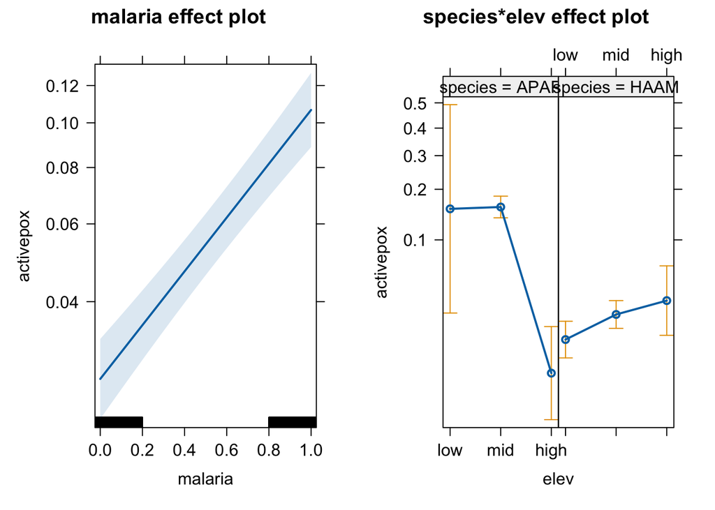

```r
plot(allEffects(pox_malaria_glm))
```